# 001_НизкийСтарт

```python
# cmd index+commit+push+to github
!git add .
!git status
!echo 0!!!
!git commit -m AutoCommit_$((Get-Date).DateTime)_$($Env:UserName)
!echo 1!!!
!git log -3
!git push
```

[output not shown]

[output not shown]

```
To https://github.com/IvanSibirevV2/HowTo_CPP.git
   a7bf191..4b3ce9d  main -> main
```

# Низкий старт

# Config

```python
from IPython.core.magic import (register_line_magic,register_cell_magic)
def Debag_Lang_Cpp(code):
    with open('main.c', mode='w') as file:file.write(code)
    !"C:\Program Files (x86)\C-Free 5\mingw\bin\\c++.exe" main.c -o Start.exe
    !Start.exe<inPut.txt
@register_line_magic
def Cpp_line(line):
    Debag_Lang_Cpp(line)
@register_cell_magic
def Cpp(line,cell):
    Debag_Lang_Cpp(cell)
@register_cell_magic
def Input(line,cell):
    with open('inPut.txt', mode='w') as file:file.write(cell)
Input(None," \n")
```

# Оглавление

# ⬇Как С/C++ на Windows 10 в 32 бита в 50 мегaбайт без лишних установок СМС и регистрации...⬇

## ⬆Оглавление⬆

# Как С/C++ на Windows 10 в 32 бита в 50 мегaбайт без лишних установок СМС и регистрации...

## ⬆Оглавление⬆

# Где Скачать

https://developerinsider.co/download-and-install-borland-c-compiler-on-windows-10/

или найти в папке с дистрибутивами и распаковать затем установить...

Затем появляется

Запускаем приложение. При первом запуске могут всплыть куча окон, безмятежно соглашаемся на все... При последующих запусках открывается окно, галку не ставим, вновь может не появиться

[figure not shown]

Если всеже напортачили и поставили галку...

[figure not shown]

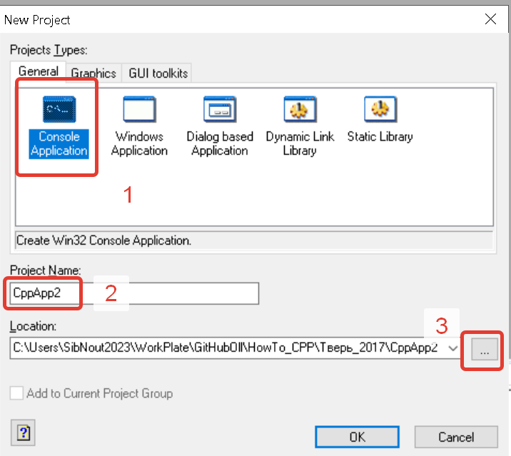

Пока что выбиарем консольное приложение. Обязательно указвываем приличное название приложения и папку для его расположения, иначе потом не найдет...

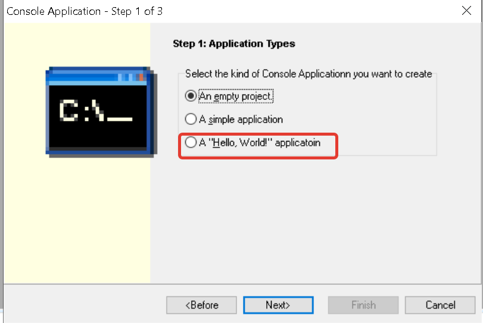

Всегда выбирайте привет мир, так как его можно запустить на предмет ошибок...

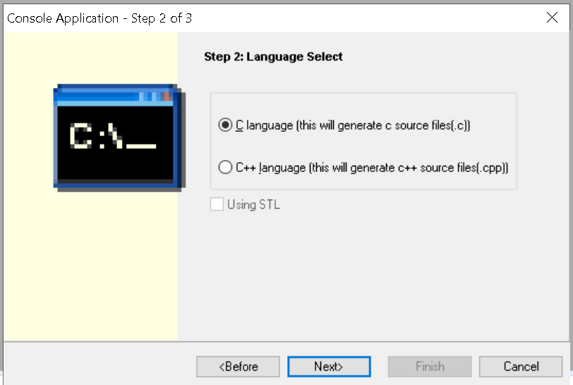

В IDE есть жесткое деление на С И С++, что радует..

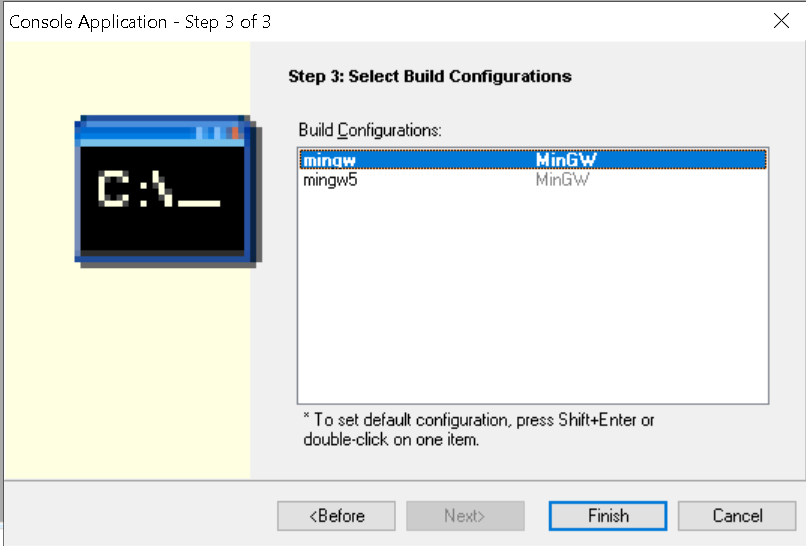

В этом я пока почти не разбираюсь, оставим на будующее

Затем открывается куча спецификаций...

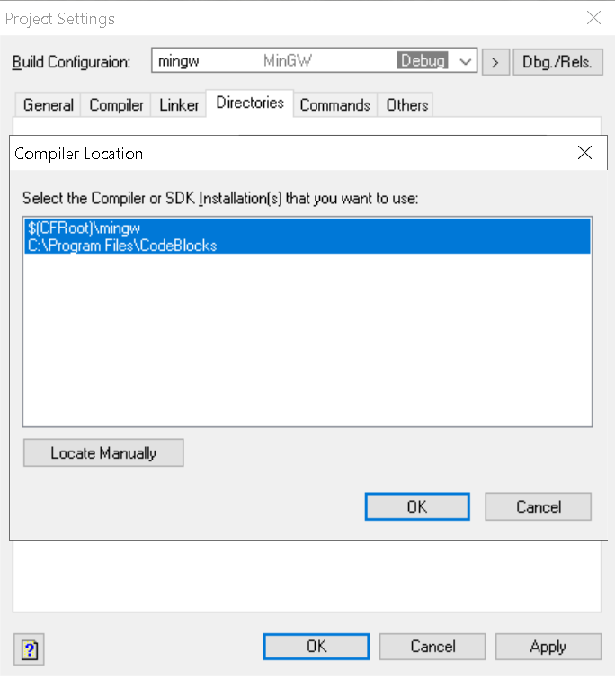

[figure not shown]

# И Так

В дальнейшем будем хранить программные коды в виде таких лекций.

```python
%%Cpp
#include <stdio.h>
int main(int argc, char *argv[])
{
	printf("Hello C-Free!\n");//\n - спец символ перехода на новую строку
	int a = 2;
	printf("a = %d\n", a);
	return 0;
}
```

```
Hello C-Free!
a = 2
```

# Отладка

По идее среда разработки подсвечивает строки с семантическими и синтаксическими ошибками. Хотелось бы когда-нибуть насладиться упакетом под Jupiter с++ под Windows. Но пока что мы пользуемся подручными средствами. В IDE обычно есть ещё и пошаговое исполнение, исполнение до точки остановки и окно локальных переменных. Нас интерисует только способ, работающий даже в блокноте. А именно, добавляем в однострочные или многострочные комментарии вообще все. Многократно раскомментируем по одной строке, и запускаем пока не найдем ошибку. Работающий программный код упаковываем в функцию с названием например Step1, оставляем все это со спокойной душой и совестью за спиной и отлаживаем код дальше. По окончании даем приличное название функции обертке...

```python
%%Cpp
#include <stdio.h>
#include <locale.h>
int main(int argc, char *argv[])
{
	setlocale(LC_ALL, "Russian");
	printf("HelloWorld\n");
 	printf("Русский текст\n");
	return 0;
}
```

```
HelloWorld
Русский текст
```

```python
%%Input
18
```

```python
%%Cpp
#include <stdio.h>
#include <locale.h>
int main(int argc, char *argv[])
{
	setlocale(LC_ALL, "Russian");
	int age, my_age;
	printf("Сколько Вам Лет\n");
	scanf("%d\n", &age);
	my_age = age + 2;
	printf("Ваш возраст: %d. Но я старше! Мой возраст - %d!!!\n", age, my_age);
	return 0;
}
//Чтение с консоли
```

```
Сколько Вам Лет
Ваш возраст: 18. Но я старше! Мой возраст - 20!!!
```

Функция scanf_s не является обязательной частью стандарта языка Си и на настоящий момент полностью поддерживается лишь в Microsoft Visual Studio. По мнению Microsoft, scanf_s является безопасной версией функции scanf (отсюда суффикс _s – secure). В других средах разработки (не от Microsoft) вы вынуждены использовать scanf вместо scanf_s, из-за того, что последняя в них не поддерживается.

```
Таблица 8.2. Спецификаторы преобразования для функции printf()
Код Формат
%a  Шестнадцатеричное в виде 0xh.hhhhp+d (только С99)
%A  Шестнадцатеричное в виде 0Xh.hhhhP+d (только С99)
%c  Символ
%d  Десятичное целое со знаком
%i  Десятичное целое со знаком
%e  Экспоненциальное представление ('е' на нижнем регистре)
%E  Экспоненциальное представление ('Е' на верхнем регистре)
%f  Десятичное с плавающей точкой
%g  В зависимости от того, какой вывод будет короче, используется %е или %f
%G  В зависимости от того, какой вывод будет короче, используется %Е или %F
%o  Восьмеричное без знака
%s  Строка символов
%u  Десятичное целое без знака
%x  Шестнадцатеричное без знака (буквы на нижнем регистре)
%X  Шестнадцатеричное без знака (буквы на верхнем регистре)
%p  Выводит указатель
%n  Аргумент, соответствующий этому спецификатору, должен быть указателем на целочисленную переменную. Спецификатор позволяет сохранить в этой переменной количество записанных символов (записанных до того места, в котором находится код %n)
%%  Выводит знак %
...
```

https://codelessons.dev/ru/printf-in-c-cplusplus/

```python
%%Cpp
#include <stdio.h>
#include <locale.h>
int main(int argc, char *argv[])
{
	setlocale(LC_ALL, "Russian");
	int value;
	value=10;//Задать десятичное число
	printf("value= %d \n", value);
	value=0010;//Задать восьмеричное число
	printf("value= %d ; %o \n", value, value);
	value=0x10;//Задать шестнадцатеричное число
	printf("value= %d ; %x \n", value, value);
	return 0;
}
```

```
value= 10
value= 8 ; 10
value= 16 ; 10
```

– char – символ,

– int – целое число,

– float – дробное число одинарной точности,

– double – дробное число двойной точности.

```python
%%Cpp
#include <stdio.h>
#include <locale.h>
int main(int argc, char *argv[])
{
	printf("1. просто строка \n");
	int _value_int=1234;
	printf("2. целое число: %d \n", _value_int);
	float _value_float=12.34;//double - ?
	printf("3. дробное число: %f \n", _value_float);
	char _value_char='C';
	printf("4. Символ: %c  \n", _value_char);
	char _value_char_array[]="C++";
	printf("5. строка: %s \n", _value_char_array);
	printf("6. процент: 100%% \n");
	return 0;
}
```

```
1. просто строка
2. целое число: 1234
3. дробное число: 12.340000
4. Символ: C
5. строка: C++
6. процент: 100%
```

```python
%%Input
3,4 4
```

```python
%%Cpp
#include <stdio.h>
#include <locale.h>
int main(){
	setlocale(LC_ALL, "Russian");
	const double pi = 3.14;
	double V, r, h;
	printf("Введите значения r и h через пробел: ");
	scanf("%lg %lg\n", &r, &h);
	printf("%lg %lg\n", r, h);
    V = pi * r * r * h;
	printf("Объем бассейна равен %lg\n", V);
	return 0;
}
/*
Введите значения r и h через пробел: 4 3
Объем бассейна равен 150,72
Для продолжения нажмите любую клавишу . . .
*/
```

```
Введите значения r и h через пробел: 3,4 4
Объем бассейна равен 145,194
```

# Упражнения

Попробуйте решить самостоятельно следующие упражнения.

1.1 Ввести с клавиатуры два числа, а затем вывести на экран результат вычисления суммы, разницы, умножения, деления и взятия остатка от деления первого на второе.

1.2 Ввести три числа, а затем вывести их среднее арифметическое.

1.3 Ввести с клавиатуры количество минут и напечатать количество целых часов и оставшихся минут. Например, 69 минут => 1 час и 9 минут, 45 минут => 0 часов и 45 минут, 254 минуты => 4 часа и 14 минут.

стр 34

Упражнения для самостоятельного решения

1.4 Ввести с клавиатуры радиус, а затем напечатать диаметр круга, длину его окружности и площадь. Для π используйте значение 3.14159. Выполните каждое вычисление внутри оператора printf и используйте спецификатор преобразования %f.

1.5 Напечатайте узор шахматной доски при помощи символов пробела и *, используя восемь операторов printf. Затем нарисуйте ту же самую картинку, используя всего лишь один оператор printf.

1.6 Ввести с клавиатуры одно пятизначное число, а затем вывести все пять цифр на печать, отделяя их пробелами. Например, если пользователь введет 31221, программа должна вывести 3 1 2 2 1.

49 стр

# Высшая математика в Си

```python
%%Cpp
#include <stdio.h>
#include <locale.h>
int main(){
	setlocale(LC_ALL, "Russian");
	int a=7, b=2, res = 0;
	float fres = 0;
	res = a+b; printf("%d + %d = %d\n",a,b,res);
	res = a-b; printf("%d - %d = %d\n",a,b,res);
	res = a*b; printf("%d * %d = %d\n",a,b,res);
	res = a%b; printf("%d %% %d = %d\n",a,b,res);
	res = a/b; printf("%d / %d = %d\n",a,b,res);
	fres = (float)a/b; printf("(float)%d / %d = %f\n",a,b,fres);
	res=getchar();
	return 0;
}
```

```
7 + 2 = 9
7 - 2 = 5
7 * 2 = 14
7 % 2 = 1
7 / 2 = 3
(float)7 / 2 = 3,500000
```

```python
%%Cpp
#include <stdio.h>
#include <locale.h>
int main(){
	setlocale(LC_ALL, "Russian");
	int a=7, b;float g= 9.81,v;
	printf("a=%d; b=%d;\n",a,b);printf("g=%f; v=%f;\n",g,v);
	b = (int)g; //приводим значение 9.81 к типу int, получим 9
	v= (float)a; // приводим значение 7 к типу float, получим 7.0
	printf("После обертывания типа...\n");
	printf("a=%d; b=%d;\n",a,b);printf("g=%f; v=%f;\n",g,v);
	int res = 0;res=getchar();
	return 0;
}
```

```
a=7; b=4199400;
g=9,810000; v=0,000000;
После обертывания типа...
a=7; b=9;
g=9,810000; v=7,000000;
```

# Тригонометрия

```python
%%Cpp
#include <stdio.h>
#include <locale.h>
#include <math.h>
int main(){
	setlocale(LC_ALL, "Russian");float a=0;
	a=-1.4;printf("fabs(%lg)=%lg;\n",a,fabs(a));
	a=4;printf("sqrt(%lg)=%lg;\n",a,sqrt(a));
	a=M_PI;printf("M_PI=%lg;\n",a);
	a=M_PI;printf("sin(%lg)=%lg; (В радианах)\n",a,sin(a));
	a=M_PI;printf("cos(%lg)=%lg; (В радианах)\n",a,cos(a));
	a=4;printf("pow(%lg, 2)=%lg; (4^2)\n",a,pow(a, 2));
	a=1;printf("exp(%lg)=%lg;\n",a,exp(a));
	a=4;printf("log(%lg)=%lg; (натуральный логарифм числа по основанию экспоненты)\n",a,log(a));
	a=4;printf("log10(%lg)=%lg; (десятичный логарифм числа по основанию экспоненты)\n",a,log10(a));
    int res = 0;res=getchar();
	return 0;
}
```

```
fabs(-1,4)=1,4;
sqrt(4)=2;
M_PI=3,14159;
sin(3,14159)=-8,74228e-008; (В радианах)
cos(3,14159)=-1; (В радианах)
pow(4, 2)=16; (4^2)
exp(1)=2,71828;
log(4)=1,38629; (натуральный логарифм числа по основанию экспоненты)
log10(4)=0,60206; (десятичный логарифм числа по основанию экспоненты)
```

# Директивы партии препроцессоров

https://prog-cpp.ru/c-directives/

- #include - включение в текст программы указанного файла... Уже использовали...
- $#include <stdio.h>$ - Если заголовочный файл содержит описание библиотечных функций и находится в папке компилятора, он заключается в угловые скобки
- $#include "func.c"$ - Если файл находится в текущем каталоге проекта, он указывается в кавычках
- #define - директика времени компиляции. Позволяет в тексте, посланном на компиляцию заменять имя директивы на её содержимое.

```python
%%Cpp
#include <stdio.h>
#include <locale.h>
#include <math.h>
#define M_EXP 2.71828
int main(){
	setlocale(LC_ALL, "Russian");
	printf("M_PI=%lg;\n",M_PI);
	printf("M_EXP=%lg;\n",M_EXP);
	int res = 0;res=getchar();
	return 0;
}
```

```
M_PI=3,14159;
M_EXP=2,71828;
```

```python
%%Cpp
#include <stdio.h>
//Макрос с параметром, аналог функции
#define sum(A,B) A+B
int main()
{
  int a, b, c, d;
  a = 3; b = 5;
  c = (a + b) * 2; // c = (a + b)*2
  d = sum(a, b) * 2; // d = a + b*2;
  printf(" a = %d\n b = %d\n", a, b);
  printf(" c = %d \n d = %d \n", c, d);
  getchar();
  return 0;
}
```

```
 a = 3
 b = 5
 c = 16
 d = 13
```

```python
%%Cpp
#include <stdio.h>
//Многострочные макросы - это очень важно
#define sum(A,B) A + \
                 B
int main()
{
  int a, b, c, d;
  a = 3; b = 5;
  c = (a + b) * 2; // c = (a + b)*2
  d = sum(a, b) * 2; // d = a + b*2;
  printf(" a = %d\n b = %d\n", a, b);
  printf(" c = %d \n d = %d \n", c, d);
  getchar();
  return 0;
}
```

```
 a = 3
 b = 5
 c = 16
 d = 13
```

```python
%%Cpp
#include <stdio.h>
//Шаблонизация макросом// По идее мы подставилине переменную а число
#define SUM(x,y) (a##x + a##y)
int main()
{
  int a1 = 5, a2 = 3;
  printf("%d", SUM(1, 2)); // (a1 + a2)
  getchar();
  return 0;
}
```

```
8
```

# инкремент декремент

# Сравнения и ветвления

# Ветвления

# Циклы с пред условием

# Цыклы с пост условием

# Цикл Фор

# Цикл фориечц

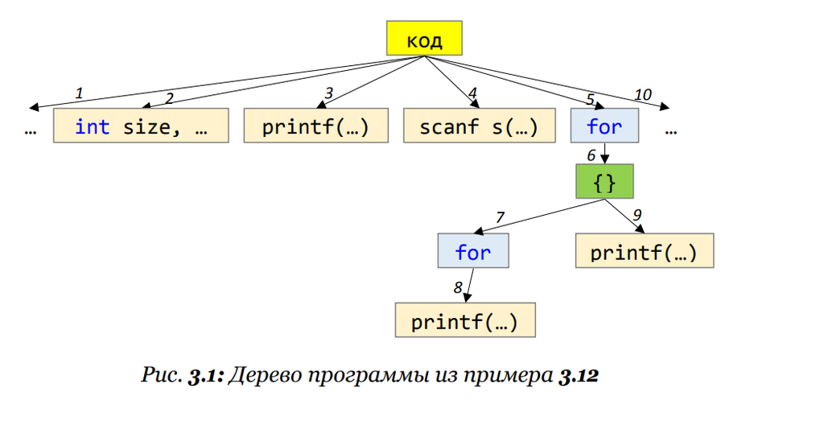

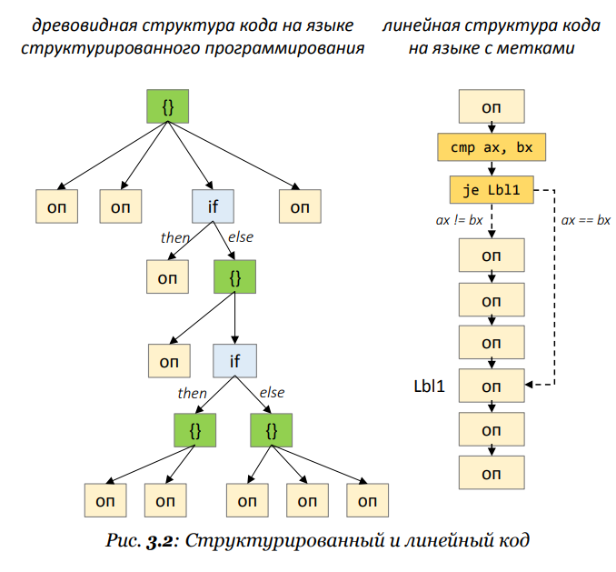

# Работа с памятью

# Всем Си